# Ultra-Processed Food Score Predictor

Daphne Rose Molina

# Introduction

This notebook loads a sample of OpenFoodFacts products that I downloaded via the API in R.  
For now, I just want to confirm that the data loads correctly and has the columns I need  
for the Ultra-Processed Food Score Predictor project.

Later, I will expand this notebook into a full pipeline (cleaning, NLP, ML).

#Setup

#Load the raw data

```r
off <- readRDS("data/raw/openfoodfacts_api_sample.rds")
dim(off)
```

```
## [1] 2000  894
```

```r
names(off)[1:20]
```

```
##  [1] "ingredients_text"
##  [2] "product_name"
##  [3] "nova_group"
##  [4] "nutriments.carbohydrates"
##  [5] "nutriments.carbohydrates_100g"
##  [6] "nutriments.carbohydrates_serving"
##  [7] "nutriments.carbohydrates_unit"
##  [8] "nutriments.carbohydrates_value"
##  [9] "nutriments.energy"
## [10] "nutriments.energy-kcal"
## [11] "nutriments.energy-kcal_100g"
## [12] "nutriments.energy-kcal_serving"
## [13] "nutriments.energy-kcal_unit"
## [14] "nutriments.energy-kcal_value"
## [15] "nutriments.energy-kcal_value_computed"
## [16] "nutriments.energy-kj"
## [17] "nutriments.energy-kj_100g"
## [18] "nutriments.energy-kj_serving"
## [19] "nutriments.energy-kj_unit"
## [20] "nutriments.energy-kj_value"
```

#Look at first few rows

```r
off %>%
as_tibble() %>%
glimpse()
```

```
## Rows: 2,000
## Columns: 894
## $ ingredients_text                                                                                                                                                                                                     <chr> …
## $ product_name                                                                                                                                                                                                         <chr> …
## $ nova_group                                                                                                                                                                                                           <int> …
## $ nutriments.carbohydrates                                                                                                                                                                                             <dbl> …
## $ nutriments.carbohydrates_100g                                                                                                                                                                                        <dbl> …
## $ nutriments.carbohydrates_serving                                                                                                                                                                                     <dbl> …
## $ nutriments.carbohydrates_unit                                                                                                                                                                                        <chr> …
## $ nutriments.carbohydrates_value                                                                                                                                                                                       <dbl> …
## $ nutriments.energy                                                                                                                                                                                                    <dbl> …
## $ `nutriments.energy-kcal`                                                                                                                                                                                             <dbl> …
## $ `nutriments.energy-kcal_100g`                                                                                                                                                                                        <dbl> …
## $ `nutriments.energy-kcal_serving`                                                                                                                                                                                     <dbl> …
## $ `nutriments.energy-kcal_unit`                                                                                                                                                                                        <chr> …
```

[output cut: 881 more lines]

#Basic cleaning: ingredients + simple nutrient features

```r
cleaned <- off %>%
filter(!is.na(nova_group)) %>%
filter(!is.na(ingredients_text)) %>%
mutate(
# clean ingredients text
ingredients_clean = ingredients_text %>%
str_to_lower() %>%
str_replace_all("[^a-z ]", " ") %>%
str_squish(),
energy_kj   = as.numeric(`nutriments.energy`),
energy_kcal = as.numeric(`nutriments.energy-kcal`)


)
```

#Check the cleaned data

```r
cleaned %>%
select(product_name, ingredients_clean, nova_group, energy_kj, energy_kcal) %>%
head(10)
```

```
##              product_name
## 1                Sidi Ali
## 2  Eau minérale naturelle
## 3                    Lait
## 4           Eau De Source
## 5    Fromage blanc nature
## 6           uht jaouda 1L
## 7                    Jben
## 8               Ain Saïss
## 9   Marmite Yeast Extract
## 10
##                                                                                                                                ingredients_clean
## 1                                                                             sodium calcium magn sium potassium bicarbonates sulfates chlorures
## 2                                                                                                                                  mineral water
## 3                                                                                           lait frais pasteuris demi cr m g l de mati re grasse
```

[output cut: 18 more lines]

## How many products in each NOVA group?

```r
cleaned %>%
  count(nova_group) %>%
  arrange(nova_group)
```

```
##   nova_group    n
## 1          1  223
## 2          2   82
## 3          3  431
## 4          4 1045
```

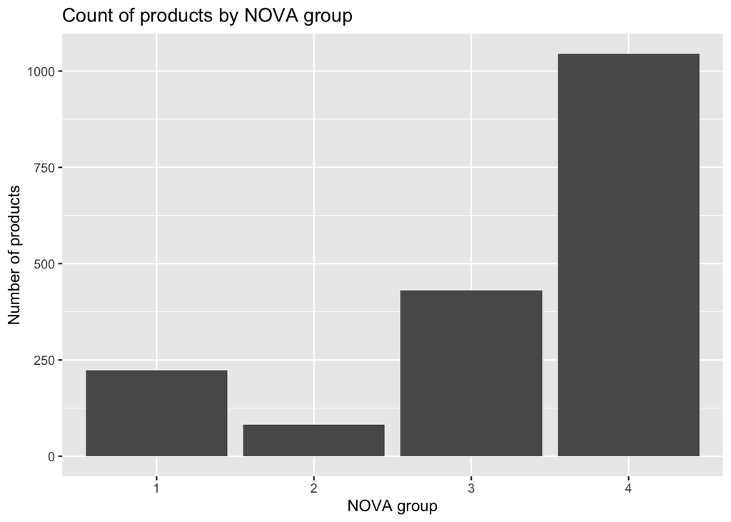

```r
cleaned %>%
  count(nova_group) %>%
  ggplot(aes(x = factor(nova_group), y = n)) +
  geom_col() +
  labs(
    x = "NOVA group",
    y = "Number of products",
    title = "Count of products by NOVA group"
  )
```

#Tokenize ingredients into individual words

```r
tokens <- cleaned %>%
  select(product_name, nova_group, ingredients_clean) %>%
  unnest_tokens(word, ingredients_clean)
```

# Look at a few tokenized rows

```r
tokens %>%
  head(15)
```

```
##              product_name nova_group         word
## 1                Sidi Ali          1       sodium
## 2                Sidi Ali          1      calcium
## 3                Sidi Ali          1         magn
## 4                Sidi Ali          1         sium
## 5                Sidi Ali          1    potassium
## 6                Sidi Ali          1 bicarbonates
## 7                Sidi Ali          1     sulfates
## 8                Sidi Ali          1    chlorures
## 9  Eau minérale naturelle          1      mineral
## 10 Eau minérale naturelle          1        water
## 11                   Lait          3         lait
## 12                   Lait          3        frais
## 13                   Lait          3    pasteuris
## 14                   Lait          3         demi
## 15                   Lait          3           cr
```

# see the most common words by NOVA

```r
word_counts <- tokens %>%
  count(nova_group, word, sort = TRUE)

# Top words for NOVA 4 (ultra-processed)
word_counts %>%
  filter(nova_group == 4) %>%
  head(20)
```

```
##    nova_group   word    n
## 1           4     de 3179
## 2           4      e  770
## 3           4      d  724
## 4           4  sucre  495
## 5           4 farine  493
## 6           4     bl  490
## 7           4   lait  444
## 8           4     ar  425
## 9           4 poudre  410
## 10          4    sel  406
## 11          4  cacao  382
## 12          4     en  362
## 13          4      l  327
## 14          4     me  322
## 15          4   soja  300
## 16          4      b  293
## 17          4  huile  292
## 18          4     et  282
## 19          4      g  282
## 20          4  sugar  276
```

#Add custom stopwords and length filter

```r
# Custom stopwords (French/connector junk)
custom_stop <- tibble::tibble(
  word = c("de", "d", "du", "des", "en", "et", "a", "au", "aux", "avec", "pour", "sur", "dans", "par", "le", "la", "les")
)

tokens_clean <- tokens %>%
  # keep only alphabetic tokens
  dplyr::filter(str_detect(word, "^[a-z]+$")) %>%
  # drop super short words (1–2 letters)
  dplyr::filter(nchar(word) >= 3) %>%
  # remove English stopwords from tidytext
  anti_join(stop_words, by = "word") %>%
  # remove our custom French/connector stopwords
  anti_join(custom_stop, by = "word")
```

#recompute word counts

```r
word_counts_clean <- tokens_clean %>%
  count(nova_group, word, sort = TRUE)

# Top words for NOVA 4 after cleaning
word_counts_clean %>%
  filter(nova_group == 4) %>%
  head(20)
```

```
##    nova_group       word   n
## 1           4      sucre 495
## 2           4     farine 493
## 3           4       lait 444
## 4           4     poudre 410
## 5           4        sel 406
## 6           4      cacao 382
## 7           4       soja 300
## 8           4      huile 292
## 9           4      sugar 276
## 10          4      flour 269
## 11          4       salt 254
## 12          4      acide 233
## 13          4     sodium 230
## 14          4        eau 228
## 15          4      wheat 211
## 16          4        oil 188
## 17          4       acid 184
## 18          4       milk 181
## 19          4 mulsifiant 177
## 20          4     beurre 175
```

Which words are especially characteristic of ultra-processed foods (NOVA 4), not just common everywhere? #TF–IDF for Ultra-Processed Foods

```r
# Count words per product (document) first
tfidf_raw <- tokens_clean %>%
  count(product_name, nova_group, word, sort = TRUE)

# Compute TF-IDF for each word within each product
tfidf <- tfidf_raw %>%
  bind_tf_idf(word, product_name, n)

# Peek at the tf-idf table
tfidf %>%
  arrange(desc(tf_idf)) %>%
  head(15)
```

```
##                                        product_name nova_group        word n
## 1                               Nuez natural pelada          1      nueces 1
## 2                                         Pistacchi          3   pistazien 1
## 3                                          اكوافينا          1        aqua 1
## 4                                   Nescafe classic          1      coffee 1
## 5                              Menguy's Peanut 100%          1  cacahuetes 1
## 6          NESCAFÉ NES, Café Soluble, Boite de 200g          1         caf 1
## 7  NESCAFÉ SPECIAL FILTRE L'Original Flacon de 200g          1         caf 1
## 8                                             Honey          2       honey 2
## 9                                       Runny Honey          2       honey 1
## 10                                  Runny Honey imp          2       honey 1
## 11                                    Squeezy Honey          2       honey 1
## 12          Aicha Double Concentré De Tomates 140 G          1     tomates 1
## 13                                 Miel de Montagne          2        miel 1
## 14                          Wasser Volvic naturelle          1      wasser 1
```

[output cut: 17 more lines]

# Average TF-IDF per word within each NOVA group

```r
tfidf_group <- tfidf %>%
  group_by(nova_group, word) %>%
  summarise(mean_tfidf = mean(tf_idf), .groups = "drop") %>%
  arrange(nova_group, desc(mean_tfidf))
```

# Top 20 most “characteristic” words for NOVA 4

```r
tfidf_group %>%
  filter(nova_group == 4) %>%
  head(20)
```

```
## # A tibble: 20 × 3
##    nova_group word               mean_tfidf
##         <int> <chr>                   <dbl>
##  1          4 agsman                  3.69
##  2          4 jnb                     3.69
##  3          4 ajr                     2.17
##  4          4 cerevisiae              1.84
##  5          4 saccharomyces           1.84
##  6          4 whipped                 1.30
##  7          4 citrone                 1.23
##  8          4 kananmuna               1.23
##  9          4 cranberry               1.13
## 10          4 gefriergetrocknete      1.11
## 11          4 acidificante            1.05
## 12          4 hidrogenado             1.05
## 13          4 morango                 1.05
## 14          4 natriumbicarbonat       1.05
## 15          4 pectinas                1.05
## 16          4 steamed                 1.05
## 17          4 taignes                 1.05
## 18          4 weins                   1.05
## 19          4 tostados                0.954
## 20          4 fasola                  0.930
```

# Add document frequency: in how many products does each word appear?

```r
tfidf_filtered <- tfidf %>%
  group_by(word) %>%
  mutate(doc_freq = n_distinct(product_name)) %>%
  ungroup() %>%
  # keep words that appear in at least 10 products
  filter(doc_freq >= 10)
```

# Recompute mean tf-idf per (nova_group, word) on this filtered set

```r
tfidf_group_filtered <- tfidf_filtered %>%
  group_by(nova_group, word) %>%
  summarise(mean_tfidf = mean(tf_idf), .groups = "drop") %>%
  arrange(nova_group, desc(mean_tfidf))
```

# Look at top 20 for NOVA 4 again

```r
tfidf_group_filtered %>%
  filter(nova_group == 4) %>%
  head(20)
```

```
## # A tibble: 20 × 3
##    nova_group word      mean_tfidf
##         <int> <chr>          <dbl>
##  1          4 fraises        0.604
##  2          4 rale           0.525
##  3          4 abricots       0.483
##  4          4 organic        0.468
##  5          4 soluble        0.415
##  6          4 lifiant        0.392
##  7          4 dates          0.385
##  8          4 vache          0.362
##  9          4 beans          0.334
## 10          4 quot           0.320
## 11          4 spice          0.317
## 12          4 chloride       0.308
## 13          4 flavors        0.304
## 14          4 milch          0.302
## 15          4 solids         0.298
## 16          4 polvo          0.290
## 17          4 rolled         0.289
## 18          4 chickpeas      0.286
## 19          4 gumes          0.279
## 20          4 poulet         0.277
```

#Build simple bag-of-words features (top 50 words)

```r
top_words <- tokens_clean %>%
  count(word, sort = TRUE) %>%
  slice_max(n, n = 50) %>%
  pull(word)

length(top_words)
```

```
## [1] 52
```

```r
head(top_words)
```

```
## [1] "lait"   "sucre"  "farine" "sel"    "salt"   "flour"
```

#document-term matrix (one row per product, one column per word)

```r
library(tidyr)

dtm <- tokens_clean %>%
  filter(word %in% top_words) %>%
  count(product_name, word) %>%
  pivot_wider(
    names_from = word,
    values_from = n,
    values_fill = 0
  )

# Check the shape
dim(dtm)
```

```
## [1] 1441   53
```

```r
head(dtm[, 1:8])
```

```
## # A tibble: 6 × 8
##   product_name                  acid acide amidon beurre cacao calcium carbonate
##   <chr>                        <int> <int>  <int>  <int> <int>   <int>     <int>
## 1 ""                               5     2      6      2    13       3         3
## 2 "0% fat Greek yoghurt"           0     0      0      0     0       0         0
## 3 "03.06.2024 DEU101H 0?:14 4"     0     0      0      1     0       1         0
## 4 "10 potato waffles"              0     0      0      0     0       0         0
## 5 "100% mie complet 500g"          0     0      0      0     0       0         0
## 6 "12 Crunchy Taco Shells"         0     0      0      0     0       0         0
```

#Build modeling dataset

```r
model_data <- cleaned %>%
  select(product_name, nova_group, energy_kcal) %>%
  inner_join(dtm, by = "product_name") %>%
  mutate(
    is_upf = if_else(nova_group == 4, 1L, 0L)
  )

dim(model_data)
```

```
## [1] 1610   56
```

```r
head(model_data[, 1:10])
```

```
##             product_name nova_group energy_kcal acid acide amidon beurre cacao
## 1               Sidi Ali          1          NA    0     0      0      0     0
## 2 Eau minérale naturelle          1          NA    0     0      0      0     0
## 3                   Lait          3        45.0    0     0      0      0     0
## 4          Eau De Source          1         0.0    0     0      0      0     0
## 5   Fromage blanc nature          3        80.6    0     0      0      0     0
## 6          uht jaouda 1L          1        58.0    0     0      0      0     0
##   calcium carbonate
## 1       1         0
## 2       0         0
## 3       0         0
## 4       0         0
## 5       0         0
## 6       0         0
```

#Train/test split

```r
set.seed(123)

n <- nrow(model_data)
train_idx <- sample(seq_len(n), size = 0.8 * n)

train <- model_data[train_idx, ]
test  <- model_data[-train_idx, ]

# Drop non-feature columns for modeling
feature_cols <- setdiff(names(train), c("product_name", "nova_group", "is_upf"))

# Build formula: is_upf ~ all features
formula_upf <- as.formula(
  paste("is_upf ~", paste(feature_cols, collapse = " + "))
)

formula_upf
```

```
## is_upf ~ energy_kcal + acid + acide + amidon + beurre + cacao +
##     calcium + carbonate + carbonates + cithines + cocoa + colza +
##     compl + contenir + eau + extract + extrait + farine + flour +
##     fruits + gluten + huile + lait + mes + milk + mulsifiant +
##     natural + naturel + oil + palme + peut + potassium + poudre +
##     powder + rapeseed + salt + sel + sodium + soja + sucre +
##     sugar + sunflower + tournesol + traces + vitamin + water +
##     concentr + graines + malt + wheat + barley + niacin + organic
```

#Fit logistic regression model

```r
fit_upf <- glm(
  formula_upf,
  data = train,
  family = binomial()
)

summary(fit_upf)
```

```
##
## Call:
## glm(formula = formula_upf, family = binomial(), data = train)
##
## Coefficients:
##               Estimate Std. Error z value Pr(>|z|)
## (Intercept)  0.2199050  0.1475834   1.490 0.136214
## energy_kcal  0.0001261  0.0003897   0.323 0.746367
## acid         0.2124747  0.1735965   1.224 0.220968
## acide        0.9316288  0.2593042   3.593 0.000327 ***
## amidon      -0.3160049  0.2919489  -1.082 0.279076
## beurre       0.7429968  0.3625319   2.049 0.040417 *
## cacao       -0.4916166  0.1619071  -3.036 0.002394 **
## calcium      0.8941757  0.2191474   4.080 4.50e-05 ***
## carbonate   -0.6884338  0.3227556  -2.133 0.032926 *
## carbonates   0.7779526  0.3361579   2.314 0.020654 *
## cithines     1.9072200  0.6237966   3.057 0.002232 **
## cocoa       -0.4216643  0.1697888  -2.483 0.013011 *
## colza        1.1455790  0.3304293   3.467 0.000526 ***
## compl       -0.3440537  0.3274846  -1.051 0.293445
## contenir     1.2418955  3.0706388   0.404 0.685888
## eau         -0.7025030  0.2077377  -3.382 0.000720 ***
## extract      0.5978951  0.2156685   2.772 0.005566 **
## extrait      1.0017369  0.3489055   2.871 0.004091 **
## farine       0.1321516  0.1438429   0.919 0.358241
## flour        0.2740702  0.1145391   2.393 0.016720 *
## fruits      -0.2690444  0.3429812  -0.784 0.432789
## gluten       0.6609710  0.2500008   2.644 0.008196 **
## huile       -0.6969376  0.2051662  -3.397 0.000681 ***
## lait        -0.3052671  0.1173954  -2.600 0.009313 **
## mes          1.9774610  0.4204164   4.704 2.56e-06 ***
## milk        -0.4109153  0.1437918  -2.858 0.004267 **
## mulsifiant   1.6162506  0.4293006   3.765 0.000167 ***
## natural      1.6585427  0.2847745   5.824 5.74e-09 ***
## naturel      1.1850041  0.3312782   3.577 0.000347 ***
## oil         -0.1126330  0.1734225  -0.649 0.516033
## palme        0.0133532  0.4365142   0.031 0.975596
## peut        -0.3843058  3.0514970  -0.126 0.899779
## potassium   -0.0660986  0.2978501  -0.222 0.824377
## poudre      -0.1428663  0.1723702  -0.829 0.407198
```

[output cut: 16 more lines]

```
## wheat       -0.2557191  0.1482469  -1.725 0.084536 .
## barley      -0.4791702  0.2799082  -1.712 0.086918 .
## niacin      -0.3451695  0.3821530  -0.903 0.366407
## organic     -0.3168420  0.1430277  -2.215 0.026743 *
## ---
## Signif. codes:  0 '***' 0.001 '**' 0.01 '*' 0.05 '.' 0.1 ' ' 1
##
## (Dispersion parameter for binomial family taken to be 1)
##
##     Null deviance: 1664.0  on 1251  degrees of freedom
## Residual deviance: 1204.4  on 1198  degrees of freedom
##   (36 observations deleted due to missingness)
## AIC: 1312.4
##
## Number of Fisher Scoring iterations: 7
```

#Evaluate on test set

```r
# Get predicted probabilities
test$prob <- predict(fit_upf, newdata = test, type = "response")

# Convert to class predictions (0/1)
test$pred <- if_else(test$prob > 0.5, 1L, 0L)

# Confusion matrix
cm <- table(
  truth = test$is_upf,
  pred  = test$pred
)
cm
```

```
##      pred
## truth   0   1
##     0  80  46
##     1  39 149
```

```r
# Accuracy (ignore any NA rows)
mean(test$pred == test$is_upf, na.rm = TRUE)
```

```
## [1] 0.7292994
```

```r
# Accuracy computed from confusion matrix
accuracy <- (cm[1,1] + cm[2,2]) / sum(cm)
accuracy
```

```
## [1] 0.7292994
```

Using a simple bag-of-words representation of the ingredient list (top 50 words) plus energy_kcal as a numeric feature, I trained a logistic regression model to predict whether a product was ultra-processed (NOVA 4) or not. On a held-out test set, the model achieved an accuracy of 73% (229 correct out of 314), with 149 correctly identified ultra-processed products and 80 correctly identified non-ultra-processed products. This shows that even a lightweight text-plus-nutrient feature set contains enough signal to meaningfully distinguish ultra-processed foods from other products.